# PS811 Portfolio

Lisa de Sousa Dias

### Research Interests

I am interested in nonviolent resistance and protest movements in sub-Sahran Africa. More specifically, I want to investigate the aftermath of protests and variation government responses and reforms. I am also interested in understanding the short and long-term consequences of violence and repression.

### Questions I hope to answer

Do protest movements catalyze government reforms? What explains variation in how governments respond to protests? How does the use of state-sponspored violence and repression impact protest movements?

### Methods

Mixed-methods. Process tracing, large-n statistical analysis, interviews, ethnogrpahy.

### Relevent data

- The Social Conflict Analysis Database (SCAD) - ( [data](https://www.strausscenter.org/scad.html)]
- The Global Digital Activism Data Set (GDADS) - ( [data](https://www.icpsr.umich.edu/icpsrweb/ICPSR/studies/34625/datadocumentation))
- The Armed Conflict Location and Event Data Project (ACLED) - ( [data](https://www.acleddata.com/data/)]
- The GDELT Project - ( [data](https://www.gdeltproject.org/data.html))

### Description of Data

```r
# d <- read.csv("~/811/data/SCAD2017Africa_Final.csv")
# Note, the above path requires that I named your repository "811" when I cloned it and that my current working directory has this folder in it.
d <- read.csv(here("data/SCAD2017Africa_Final.csv"))

variables <- c("countryname", "eyr", "etype", "ndeath", "repress")
protests <- d[variables] # or d %<>% select(variables)

summary(protests)
```

```
##        countryname        eyr           etype            ndeath
##  Nigeria     :2363   Min.   :1990   Min.   :-9.000   Min.   : -99.000
##  Egypt       :1984   1st Qu.:2001   1st Qu.: 2.000   1st Qu.:   0.000
##  South Africa:1287   Median :2011   Median : 6.000   Median :   0.000
##  Libya       : 820   Mean   :2007   Mean   : 5.255   Mean   :   9.713
##  Somalia     : 794   3rd Qu.:2014   3rd Qu.: 8.000   3rd Qu.:   4.000
##  Kenya       : 772   Max.   :2016   Max.   :10.000   Max.   :5000.000
##  (Other)     :8090
##     repress
##  Min.   :0.0000
##  1st Qu.:0.0000
##  Median :0.0000
##  Mean   :0.3782
##  3rd Qu.:1.0000
##  Max.   :2.0000
##
```

```r
glimpse(protests)
```

```
## Observations: 16,110
## Variables: 5
## $ countryname <fct> Guinea-Bissau, Guinea-Bissau, Guinea-Bissau, Guinea-…
## $ eyr         <int> 1995, 1996, 1996, 1997, 1999, 1999, 1999, 1999, 2000…
## $ etype       <int> 5, 4, 2, 2, -9, 1, 3, 1, 4, 7, 7, 8, 6, 3, 6, 8, 6, …
## $ ndeath      <int> 0, 0, 0, 0, -77, 0, 0, 0, 1, 0, -99, 30, 0, 0, 0, 0,…
## $ repress     <int> 0, 1, 0, 0, 2, 0, 1, 0, 1, 0, 0, 0, 0, 1, 0, 1, 0, 0…
```

### Number of Protests Events in Africa

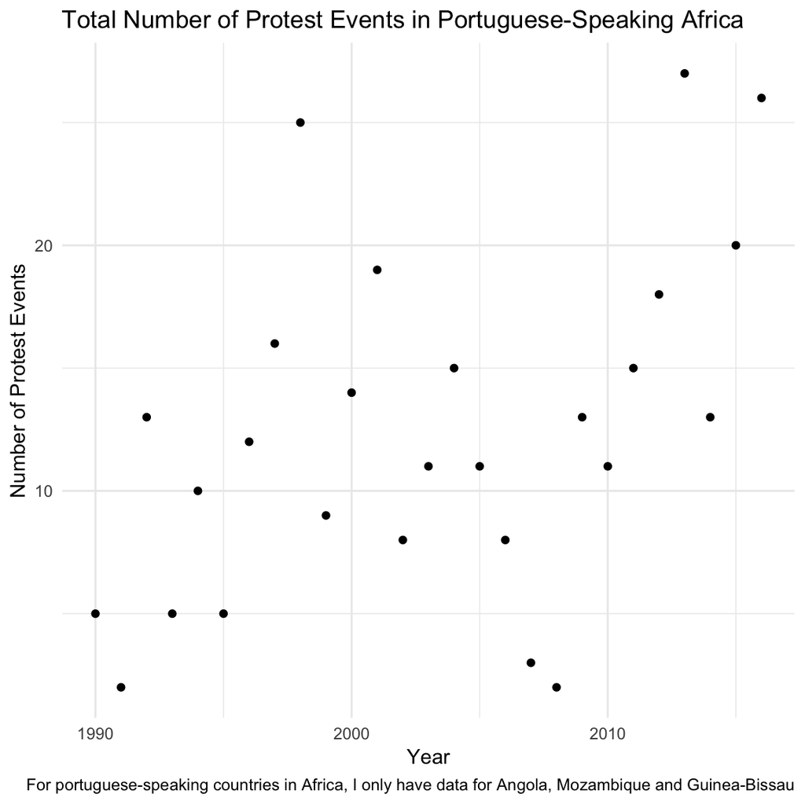

```r
### Number of protest events in portuguese-speaking Africa

# protests <- read.csv("~/811/data/protests.csv")
protests <- read.csv(here("data/protests.csv"))

## Solid object names :)
portuguese_speaking_countries <- filter(protests, protests$countryname %in% c("Angola", "Mozambique", "Guinea-Bissau"))

number_events <- portuguese_speaking_countries %>% group_by(eyr)

number_events_per_year <- number_events %>% tally()

ggplot(number_events_per_year) +
         geom_point(aes(eyr, n)) +
  labs(x = "Year", y = "Number of Protest Events", title = "Total Number of Protest Events in Portuguese-Speaking Africa", caption = "For portuguese-speaking countries in Africa, I only have data for Angola, Mozambique and Guinea-Bissau")
```

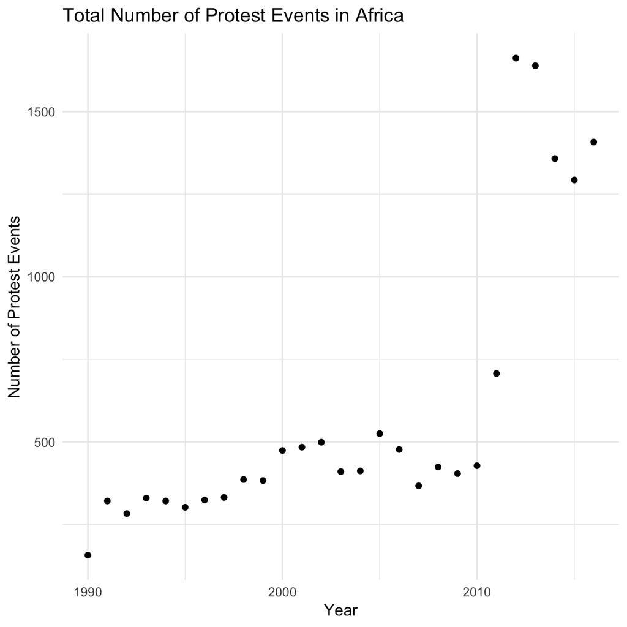

```r
### Graph for Number of Protest Events in the whole of Africa

number_events_all <- protests %>% group_by(eyr)

number_events_per_year_all <- number_events_all %>%tally()

ggplot(number_events_per_year_all) +
  geom_point(aes(eyr, n)) +
  labs(x = "Year", y = "Number of Protest Events", title = "Total Number of Protest Events in Africa")
```

### Question about ggplot

Hi Devin,

I’m trying to plot a graph where I have basically the same two axes as my two graphs above (x=year, y=total number of protest events), but where I have different lines on the graph for each of the countries (I currently have a single point for all the countries combined). For example, I want to be able to look at different lines for Angola, Mozambqiue and Guinea-Bissau in the first graph. I’ve tried to use different combinations of the tally/filter functions, but I can’t figure out how to create lines for each country.

### Number of Protests in Portuguese Speaking Africa

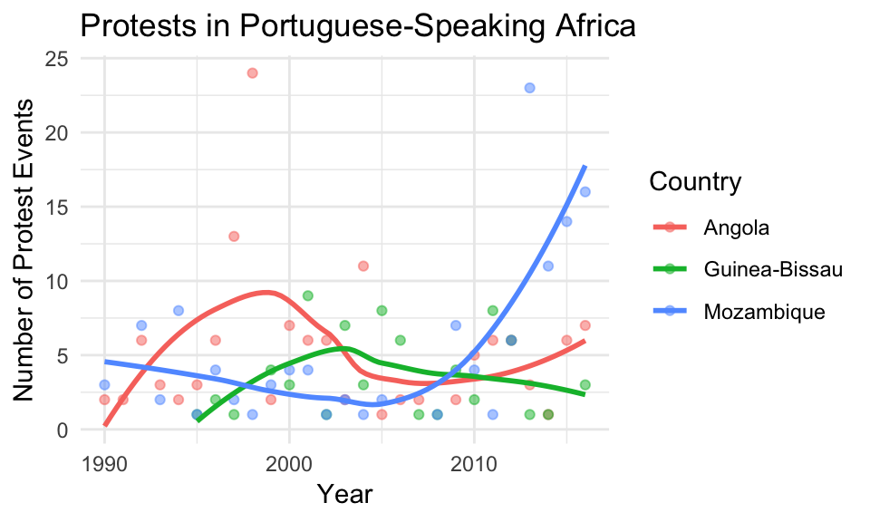

```r
d <- protests
d %>%
  filter(countryname %in% c("Angola", "Mozambique", "Guinea-Bissau") ) %>%
  group_by(countryname, eyr) %>%
  tally() %>%
ggplot( aes(x = eyr, y = n, color = countryname)) +
  geom_point(alpha = .5) +
  geom_smooth(se=F) +
  labs(x = "Year",
       y = "Number of Protest Events",
       color = "Country",
       title = "Protests in Portuguese-Speaking Africa")
```